# What are hypothesis tests doing?

# Background

> What is the purpose of these notes?
1. Provide a few small examples of hypothesis tests on simulated data;
2. Give you several lines of `R` code you can use in this course.

> What is the format of this document?

This document was created using `R Markdown`. You can read more about it [here](https://www.markdownguide.org/getting-started/) and check out a [cheat sheet here](https://rstudio.com/wp-content/uploads/2015/02/rmarkdown-cheatsheet.pdf), which will guide you through installing RStudio, and from there the moment you create a new `.Rmd` document, it will be a working template to start from. If you are used to using `LaTeX`, no worries: it can be embedded into `Markdown`, with overall simpler formatting. I hope you find this useful!

### Installing and loading packages

Just like every other programming language you may be familiar with, R’s capabilities can be greatly extended by installing additional “packages” and “libraries”.

To **install** a package, use the `install.packages()` command. You’ll want to run the following commands to get the necessary packages for these notes:

```
install.packages("tidyverse")
```

You only need to install packages once. Once they’re installed, you may use them by **loading** the libraries using the `library()` command. For these notes, you’ll want to run the following code

```
library("tidyverse")
options(scipen = 4)  # Suppresses scientific notation
library("tigerstats")
```

# Context

As we learned in the first half of the semester, *statistics* are functions of random variables and therefore are random variables themselves. In particular, they have their own distributions, called *sampling distributions*. Our inferred knowledge about these distributions is used to *estimater parameters* of the model which we postulate was used to generate the data.

So far we have learned about *point estimators*. Next, we will learn about *interval estimators*. And now, we focus on hypothesis tests. In other notes, we discuss the general view of how these fit together.

> You will see later in the course that hypothesis tests are very useful in the addressing the question *whether the postulated model was indeed used to generate the data*.

# A simulated example

*(What is statistical significance testing doing?)*

Here’s a little simulation where we have two groups, a treatment groups and a control group. We’re going to simulate observations from both groups. We’ll run the simulation two ways.

- First simulation (Null case): the treatment has no effect
- Second simulation (Non-null case): the treatment on average increases outcome

```r
set.seed(12345)
# Function to generate data
generateSimulationData <- function(n1, n2, mean.shift = 0) {
  y <- rnorm(n1 + n2) + c(rep(0, n1), rep(mean.shift, n2))
  groups <- c(rep("control", n1), rep("treatment", n2))
  data.frame(y = y, groups = groups)
}
```

Let’s look at a single realization in the null setting.

```r
n1 = 30
n2 = 40
# Observation, null case
obs.data <- generateSimulationData(n1 = n1, n2 = n2)
obs.data[c(1,n1,n1+1,n2),]
```

```
             y    groups
1   0.58552882   control
30 -0.16231098   control
31  0.81187318 treatment
40  0.02580105 treatment
```

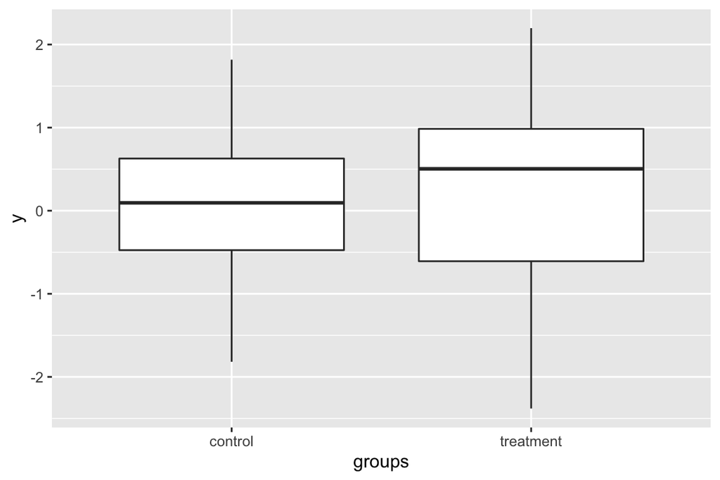

```r
# Box plots
qplot(x = groups, y = y, data = obs.data, geom = "boxplot")
```

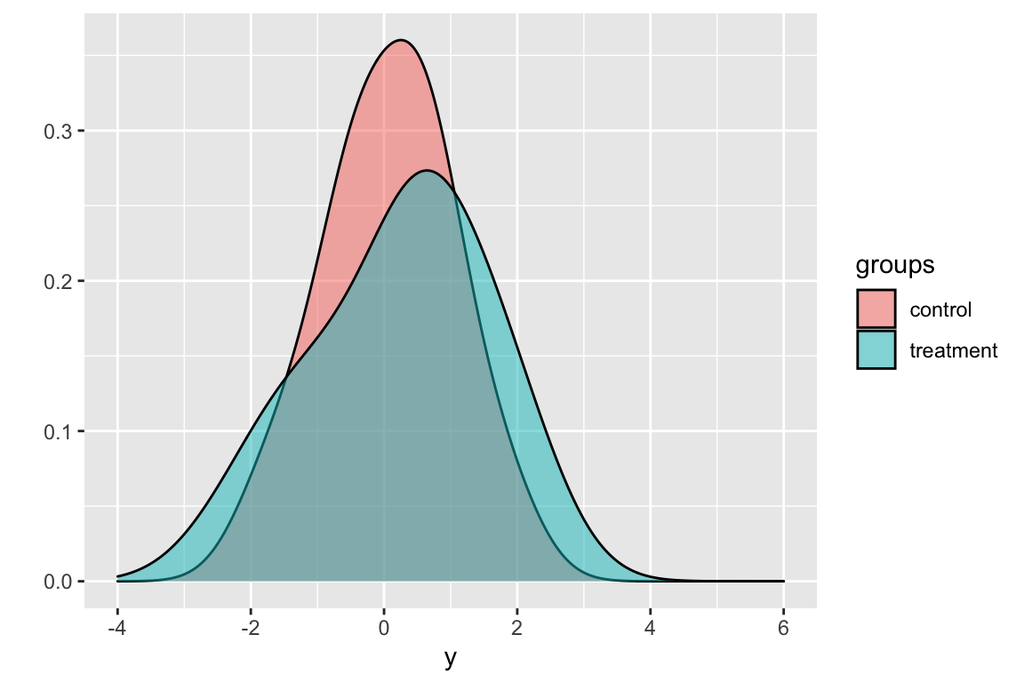

```r
# Density plots
qplot(fill = groups, x = y, data = obs.data, geom = "density",
      alpha = I(0.5),
      adjust = 1.5,
      xlim = c(-4, 6))
```

```r
# t-test
t.test(y ~ groups, data = obs.data)
```

```
    Welch Two Sample t-test

data:  y by groups
t = -0.61095, df = 67.998, p-value = 0.5433
alternative hypothesis: true difference in means is not equal to 0
95 percent confidence interval:
 -0.6856053  0.3641889
sample estimates:
  mean in group control mean in group treatment
             0.07880701              0.23951518
```

And here’s what happens in a random realization in the non-null setting.

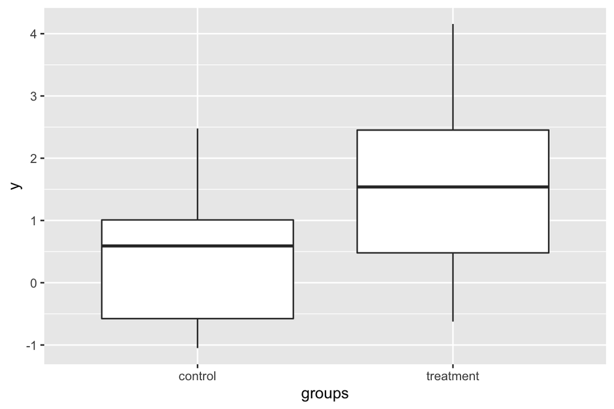

```r
# Non-null case, very strong treatment effect
# Observation, null case
obs.data <- generateSimulationData(
  n1 = n1, n2 = n2, mean.shift = 1.5)

# Box plots
qplot(x = groups, y = y, data = obs.data, geom = "boxplot")
```

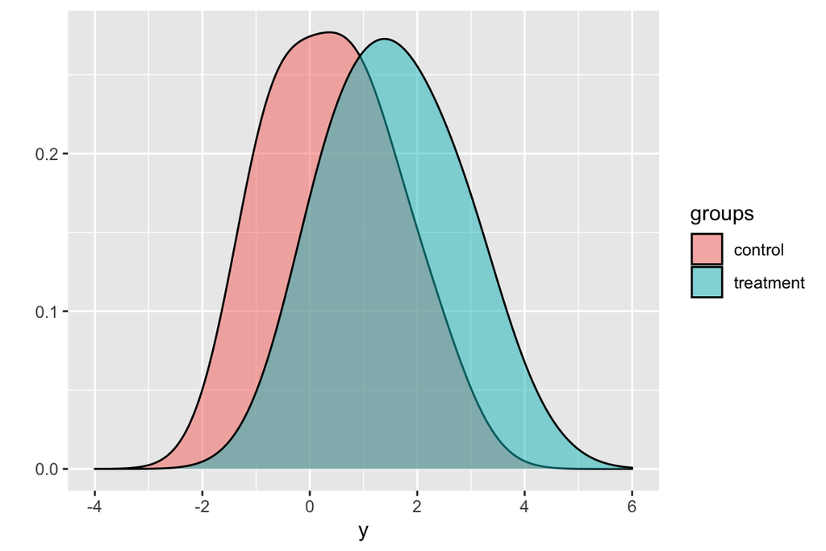

```r
# Density plots
qplot(fill = groups, x = y, data = obs.data, geom = "density",
      alpha = I(0.5),
      adjust = 1.5,
      xlim = c(-4, 6))
```

```r
# t-test
t.test(y ~ groups, data = obs.data)
```

```
    Welch Two Sample t-test

data:  y by groups
t = -4.3081, df = 64.785, p-value = 0.00005708
alternative hypothesis: true difference in means is not equal to 0
95 percent confidence interval:
 -1.6911828 -0.6197985
sample estimates:
  mean in group control mean in group treatment
              0.4191634               1.5746541
```